# **APRENDIZAJE AUTOMATICO Y CIENCIA DE DATOS**

ENTREGA 1: CONTEXTO Y EXPLORACION DE DATOS

Cesar Augusto Prieto Sarmiento

Universidad Nacional de Colombia  
Departamento de Estadística

ceprieto@unal.edu.co

# **DESCRIPCIÓN DE LA BASE**

La base de datos fue tomada de el repositorio de Dataset’s de Hugging Face https://huggingface.co/datasets/imodels/diabetes-readmission Esta a su vez tiene un link directo a la página de Machine Learning Repository el cual contiene la ficha tecnica completa de la base.

## CRITERIOS DE INCLUSIÓN

Para formar parte de esta base de datos, cada registro debe cumplir con los siguientes criterios:

1. **Encuentros hospitalarios**: El registro corresponde a una admisión hospitalaria.
2. **Diagnóstico de diabetes**: Se incluye cualquier diagnóstico relacionado con diabetes en el sistema.
3. **Duración de la estancia**: Entre 1 y 14 días.
4. **Pruebas de laboratorio**: Se realizaron análisis clínicos durante la estancia.
5. **Administración de medicamentos**: Incluye la administración de medicamentos durante el encuentro.

# **CONTEXTO**

El manejo hospitalario de pacientes con diabetes es un desafío importante debido a las múltiples complicaciones asociadas con la enfermedad. Este dataset busca abordar una problemática específica: **la readmisión temprana dentro de los 30 días posteriores al alta hospitalaria**.

La diabetes es una enfermedad crónica que requiere una atención continua y adecuada. A pesar de la evidencia sólida que respalda el impacto positivo de las intervenciones preventivas y terapéuticas, existe una brecha significativa entre las prácticas ideales y la atención real proporcionada en los hospitales. Este problema puede atribuirse, en parte, a una gestión inconsistente de la diabetes en los entornos hospitalarios, particularmente en el control glucémico.

El impacto de una atención inadecuada va más allá de los resultados clínicos inmediatos. Los pacientes enfrentan un mayor riesgo de complicaciones, mientras que los hospitales deben absorber costos adicionales derivados de readmisiones evitables.

# **ANTECEDENTES**

El análisis de esta base de datos se publicó en el artículo titulado *“Impact of HbA1c Measurement on Hospital Readmission Rates: Analysis of 70,000 Clinical Database Patient Records”*, escrito por Beata Strack y colaboradores, y publicado en la revista BioMed Research International en 2014.

El objetivo principal del análisis fue investigar los factores asociados con la readmisión temprana de pacientes hospitalizados con diabetes, con un enfoque particular en la medición del HbA1c, un marcador clave para el control glucémico. Este análisis se basa en más de 50 variables que describen las características de los pacientes, los tratamientos realizados y los resultados hospitalarios.

Algunos de los atributos más destacados del dataset incluyen:

- **Datos demográficos**: Número de paciente, raza, género y edad.
- **Datos clínicos**: Tipo de admisión, tiempo en el hospital, especialidad médica del médico tratante.
- **Pruebas y tratamientos**: Número de análisis de laboratorio realizados, resultados de pruebas de HbA1c, medicamentos administrados, y tratamientos relacionados con la diabetes.
- **Historial médico**: Número de visitas a consultas externas, hospitalizaciones y emergencias en el año anterior a la admisión actual.

No se recomiendan divisiones específicas de datos, por lo que pueden emplearse estrategias estándar como la división en conjuntos de entrenamiento, validación y prueba según el modelo analítico.

Este reporte busca proporcionar una visión integral del dataset, estableciendo las bases para explorar y modelar los factores determinantes de las readmisiones hospitalarias de pacientes con diabetes.

# **ANÁLISIS UNIVARIADO**

```
## Rows: 101,763
## Columns: 151
## $ time_in_hospital                                    <dbl> 4, 2, 4, 5, 1, 7, …
## $ num_lab_procedures                                  <dbl> 66, 48, 21, 38, 6,…
## $ num_procedures                                      <dbl> 3, 0, 3, 0, 0, 2, …
## $ num_medications                                     <dbl> 18, 15, 23, 5, 6, …
## $ number_outpatient                                   <dbl> 0, 4, 1, 0, 0, 0, …
## $ number_emergency                                    <dbl> 0, 0, 0, 0, 0, 0, …
## $ number_inpatient                                    <dbl> 1, 0, 2, 0, 0, 0, …
## $ number_diagnoses                                    <dbl> 9, 7, 7, 2, 6, 2, …
## $ change                                              <dbl> 1, 0, 0, 1, 0, 1, …
## $ diabetesMed                                         <dbl> 1, 0, 1, 1, 1, 1, …
## $ `race:AfricanAmerican`                              <dbl> 0, 0, 0, 0, 0, 0, …
## $ `race:Asian`                                        <dbl> 0, 0, 0, 0, 0, 0, …
## $ `race:Caucasian`                                    <dbl> 1, 1, 1, 1, 0, 1, …
```

[output cut: 138 more lines]

Podemos observar como hay algunas variables que son de tipo factor y otras de tipo integer, luego de hacer una revisión minuciosa de la base de datos, se decidió explorar la distribucion de las variables y a la par unir aquellas que se refieren a lo mismo, para tener una mejor visualización de los datos y poder hacer un analisis mas detallado de los mismos.

## **VARIABLES CATEGÓRICAS**

A continuacion, se propuso la union de las varibles que hacen referencia a lo mismo, para tener una mejor visualizacion de los datos y poder hacer un analisis mas detallado de los mismos, se presenta un análisis de cada variable categórica presente en el dataset, incluyendo su distribución de frecuencias y niveles asociados:

### DIABETESMED

La variable “diabetesMed” indica si los pacientes reciben medicación para la diabetes.

Proporciones de las variables en DiabetesMed

| Variable | Proporción |
| --- | --- |
| diabetesMed | 0.7700343 |

Una proporción significativa (77.00%) de los pacientes está bajo tratamiento, lo que refleja que la mayoría de los casos en la muestra requieren manejo farmacológico para controlar la diabetes.

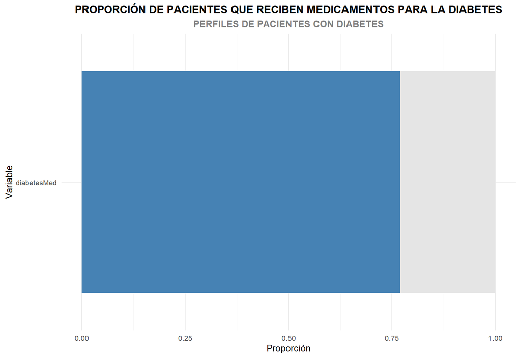

```r
T_Proportion_diabetesMed %>%
  mutate(Sobrante = 1 - Proporcion) %>%
  ggplot(aes(x = reorder(Variable, Proporcion))) +
  geom_bar(aes(y = 1), stat = "identity", fill = "grey90") +  # Barra gris del 100%
  geom_bar(aes(y = Proporcion), stat = "identity", fill = "steelblue") +  # Barra azul de la proporción
  coord_flip() +
  ggtitle(label = "PROPORCIÓN DE PACIENTES QUE RECIBEN MEDICAMENTOS PARA LA DIABETES",
          subtitle = "PERFILES DE PACIENTES CON DIABETES") +
  labs(x = "Variable", y = "Proporción") +
  theme_minimal() +
  theme(plot.title = element_text(size = 12, face = "bold", hjust = 0.5),
        legend.position = "none", text = element_text(size = 10),
        plot.subtitle = element_text(size = 10, face = "bold", hjust = 0.5, color = "grey50"))
```

### CHANGE

La variable “change” indica si hubo modificaciones en la medicación de los pacientes durante su atención.

Proporciones de las variables en Change

| Variable | Proporción |
| --- | --- |
| change | 0.4619459 |

Una proporción considerable (46.19%) de los pacientes experimentó cambios en su tratamiento, lo que sugiere ajustes frecuentes en el manejo médico para optimizar el control de la diabetes u otras condiciones relacionadas.

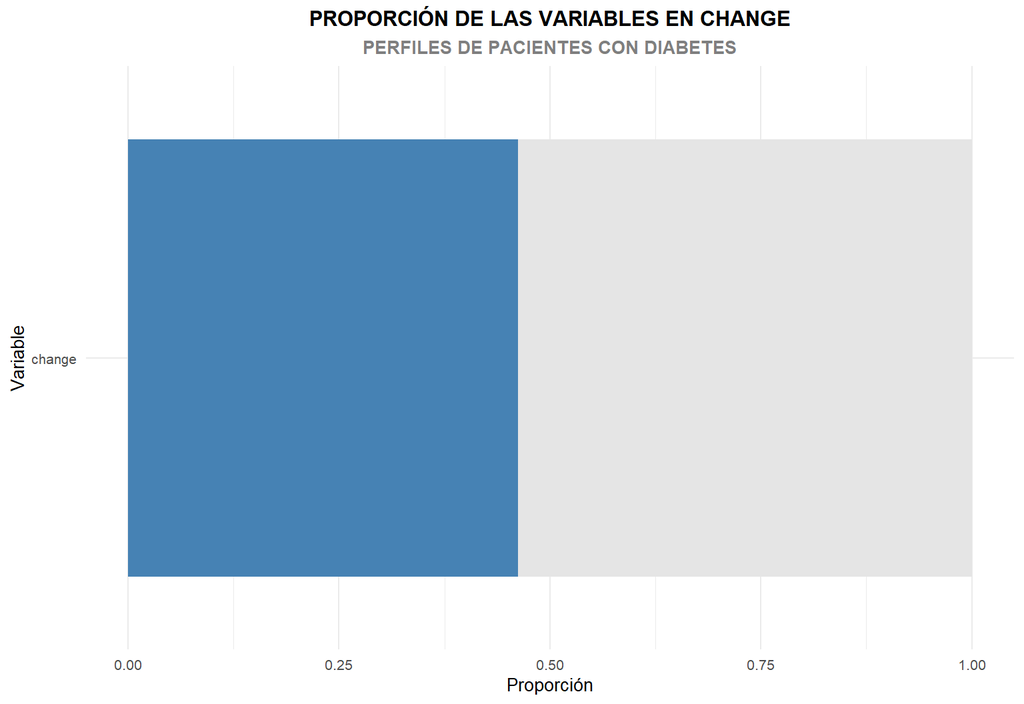

```r
T_Prop_change %>%
  mutate(Sobrante = 1 - Proporcion) %>%
  ggplot(aes(x = reorder(Variable, Proporcion))) +
  geom_bar(aes(y = 1), stat = "identity", fill = "grey90") +  # Barra gris del 100%
  geom_bar(aes(y = Proporcion), stat = "identity", fill = "steelblue") +  # Barra azul de la proporción
  coord_flip() +
  ggtitle(label = "PROPORCIÓN DE LAS VARIABLES EN CHANGE",
          subtitle = "PERFILES DE PACIENTES CON DIABETES") +
  labs(x = "Variable", y = "Proporción") +
  theme_minimal() +
  theme(plot.title = element_text(size = 12, face = "bold", hjust = 0.5),
        legend.position = "none", text = element_text(size = 10),
        plot.subtitle = element_text(size = 10, face = "bold", hjust = 0.5, color = "grey50"))
```

### RAZA

La variable “raza” muestra la distribución racial de los individuos en el conjunto de datos, lo cual es relevante para entender la diversidad y las posibles disparidades en ciertos contextos, como la salud o la educación.

Proporciones de las variables en Raza

|  | Variable | Proporción |
| --- | --- | --- |
| 3 | race:Caucasian | 0.7478062 |
| 1 | race:AfricanAmerican | 0.1887720 |
| 5 | race:Other | 0.0371058 |
| 4 | race:Hispanic | 0.0200171 |
| 2 | race:Asian | 0.0062989 |

La categoría caucásica representa la mayoría (74.78%), seguida por la afroamericana (18.88%), mientras que las razas “otros”, hispano y asiático tienen una proporción mucho menor, lo que sugiere una posible falta de representación o sesgo en la muestra hacia estos grupos, todo esto se puede ver en la siguiente grafica

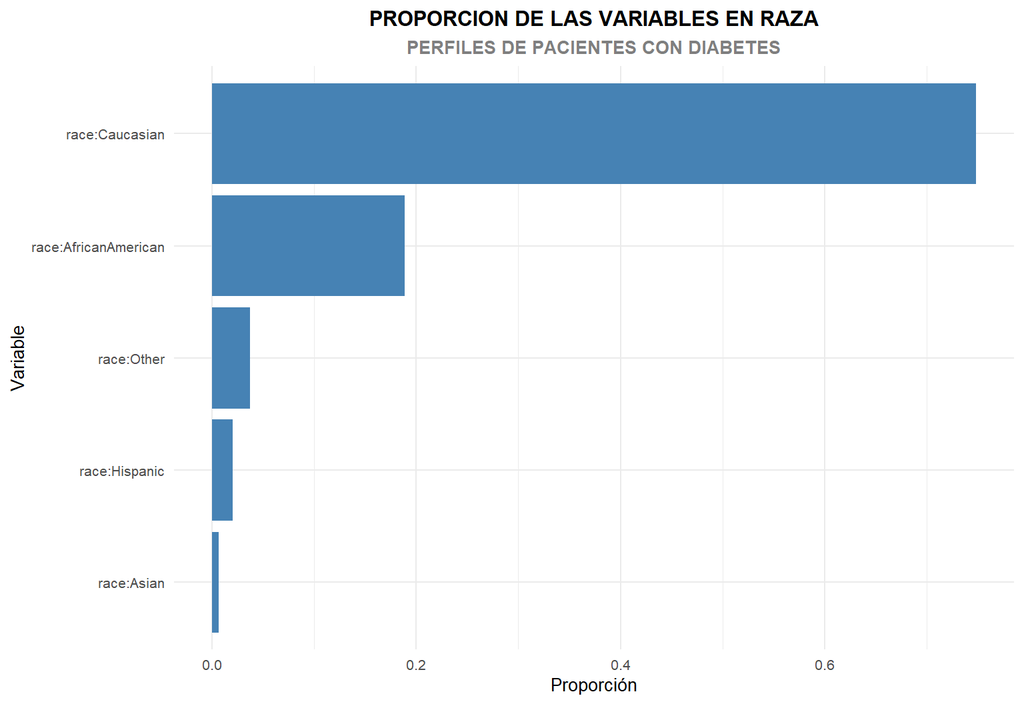

```r
T_Prop_Raza %>%
  ggplot(aes(x = reorder(Variable, Proporcion), y = Proporcion)) +
  geom_bar(stat = "identity", fill = "steelblue") +
  coord_flip() +
  ggtitle(label = "PROPORCION DE LAS VARIABLES EN RAZA",
          subtitle = "PERFILES DE PACIENTES CON DIABETES") +
  labs(x = "Variable", y = "Proporción") +
  coord_flip() +
  theme_minimal() +
  theme(plot.title = element_text(size = 12, face = "bold", hjust = 0.5),
        legend.position = "none", text = element_text(size = 10),
        plot.subtitle = element_text(size = 10, face = "bold", hjust = 0.5, color = "grey50"))
```

### GENERO

La variable “género” refleja la distribución entre hombres y mujeres en el conjunto de datos, lo cual es importante para identificar posibles diferencias de género en análisis relacionados con salud, oportunidades o comportamientos.

Proporciones de las variables en Genero

| Variable | Proporción |
| --- | --- |
| gender:Female | 0.5376021 |
| gender:Male | 0.4623979 |

La categoría femenina representa el 53.76%, mientras que los hombres constituyen el 46.24%, lo que sugiere una distribución casi equitativa entre ambos géneros en la muestra.

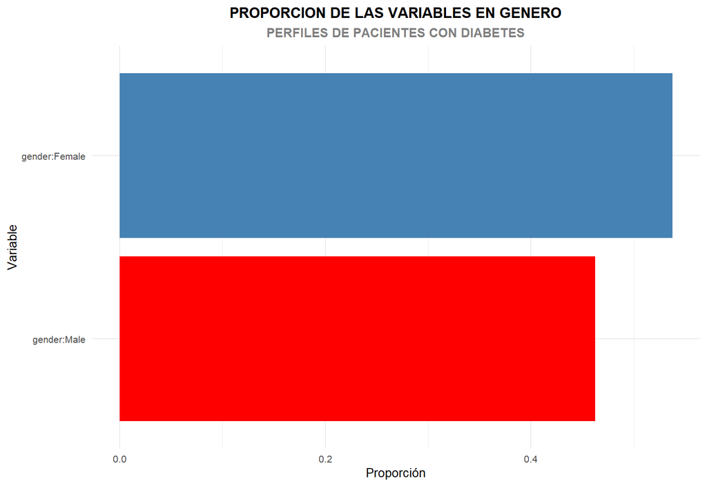

```r
T_Prop_Genero %>%
  ggplot(aes(x = reorder(Variable, Proporcion), y = Proporcion)) +
  geom_bar(stat = "identity", fill = c("steelblue", "red")) +
  coord_flip() +
  ggtitle(label = "PROPORCION DE LAS VARIABLES EN GENERO",
          subtitle = "PERFILES DE PACIENTES CON DIABETES") +
  labs(x = "Variable", y = "Proporción") +
  coord_flip() +
  theme_minimal() +
  theme(plot.title = element_text(size = 12, face = "bold", hjust = 0.5),
        legend.position = "none", text = element_text(size = 10),
        plot.subtitle = element_text(size = 10, face = "bold", hjust = 0.5, color = "grey50"))
```

### EDAD

La variable “edad” muestra la distribución de las personas en diferentes rangos de edad, lo cual es crucial para analizar cómo varían ciertos factores según la edad.

Proporciones de las variables en Edad

|  | Variable | Proporción |
| --- | --- | --- |
| 5 | age:70+ | 0.4525810 |
| 4 | age:[50-70) | 0.3904956 |
| 3 | age:[20-50) | 0.1485510 |
| 2 | age:[10-20) | 0.0067903 |
| 1 | age:[0-10) | 0.0015821 |

La mayoría de los individuos se encuentran en el grupo de 70+ años (45.26%) y en el grupo de 50-70 años (39.05%). Los grupos más jóvenes, como el de 20-50 años, representan una proporción más pequeña (14.85%), mientras que los rangos de 10-20 años y 0-10 años tienen representaciones mínimas, lo que podría indicar que los datos están más enfocados en adultos mayores.

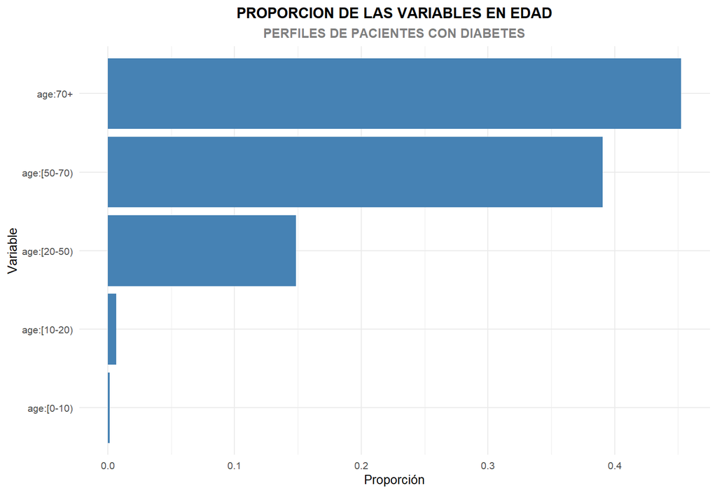

```r
T_Prop_Edad %>%
  ggplot(aes(x = reorder(Variable, Proporcion), y = Proporcion)) +
  geom_bar(stat = "identity", fill = "steelblue") +
  coord_flip() +
  ggtitle(label = "PROPORCION DE LAS VARIABLES EN EDAD",
          subtitle = "PERFILES DE PACIENTES CON DIABETES") +
  labs(x = "Variable", y = "Proporción") +
  coord_flip() +
  theme_minimal() +
  theme(plot.title = element_text(size = 12, face = "bold", hjust = 0.5),
        legend.position = "none", text = element_text(size = 10),
        plot.subtitle = element_text(size = 10, face = "bold", hjust = 0.5, color = "grey50"))
```

### TIPO DE ADMISION

La variable “tipo de admisión” indica las razones por las cuales los pacientes ingresan al sistema de salud, lo que es importante para entender la urgencia y la naturaleza de los casos.

Proporciones de las variables en Tipo de Admision

|  | Variable | Proporción |
| --- | --- | --- |
| 2 | admission_type_id:Emergency | 0.7121252 |
| 1 | admission_type_id:Elective | 0.1854112 |
| 4 | admission_type_id:Trauma Center | 0.0002064 |
| 3 | admission_type_id:New Born | 0.0000983 |

La mayoría de las admisiones son por emergencia, representando el 71.21%, seguido por las admisiones electivas (18.54%). Las admisiones por trauma y por recién nacidos son mínimas, con proporciones de 0.02% y 0.01% respectivamente, lo que sugiere que los casos más urgentes son los más comunes en esta muestra.

#### GRF CON

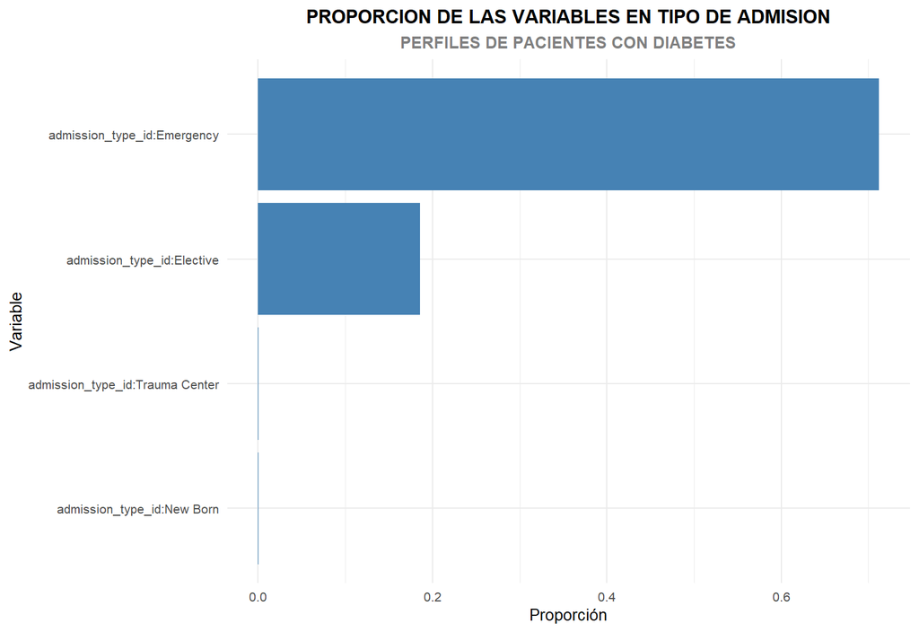

```r
T_Prop_Admision %>%
  ggplot(aes(x = reorder(Variable, Proporcion), y = Proporcion)) +
  geom_bar(stat = "identity", fill = "steelblue") +
  coord_flip() +
  ggtitle(label = "PROPORCION DE LAS VARIABLES EN TIPO DE ADMISION",
          subtitle = "PERFILES DE PACIENTES CON DIABETES") +
  labs(x = "Variable", y = "Proporción") +
  coord_flip() +
  theme_minimal() +
  theme(plot.title = element_text(size = 12, face = "bold", hjust = 0.5),
        legend.position = "none", text = element_text(size = 10),
        plot.subtitle = element_text(size = 10, face = "bold", hjust = 0.5, color = "grey50"))
```

#### GRF SIN

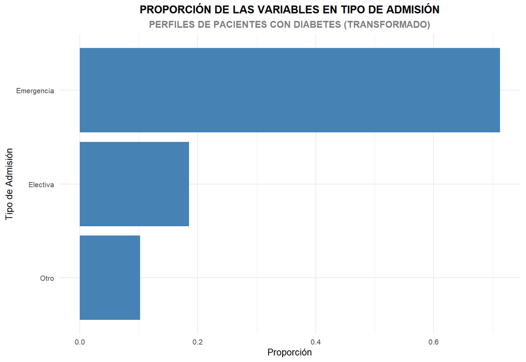

```r
T_Prop_Admision_Trans %>%
  ggplot(aes(x = reorder(Admision, Proporcion), y = Proporcion)) +
  geom_bar(stat = "identity", fill = "steelblue") +
  coord_flip() +
  ggtitle(label = "PROPORCIÓN DE LAS VARIABLES EN TIPO DE ADMISIÓN",
          subtitle = "PERFILES DE PACIENTES CON DIABETES (TRANSFORMADO)") +
  labs(x = "Tipo de Admisión", y = "Proporción") +
  theme_minimal() +
  theme(plot.title = element_text(size = 12, face = "bold", hjust = 0.5),
        legend.position = "none", text = element_text(size = 10),
        plot.subtitle = element_text(size = 10, face = "bold", hjust = 0.5, color = "grey50"))
```

### DISCHARGE

La variable “disposición de alta” refleja el destino de los pacientes al ser dados de alta, lo cual es relevante para entender el seguimiento y los cuidados posteriores.

Proporciones de las variables en Discharge

| Variable | Proporción |
| --- | --- |
| discharge_disposition_id:Discharged to Home | 0.7237306 |
| discharge_disposition_id:Other | 0.2302802 |

La mayoría de los pacientes (72.37%) son dados de alta para regresar a casa, mientras que una proporción significativa (23.03%) es clasificada bajo “otros”, lo que podría indicar una variedad de destinos, como instituciones de cuidado o traslados a otros centros médicos.

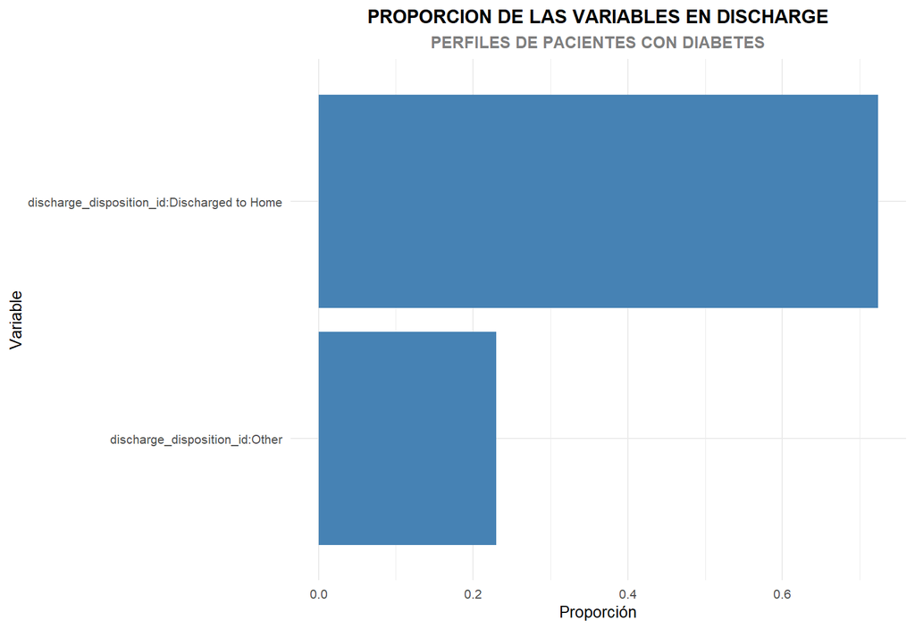

```r
T_Prop_Discharge %>%
  ggplot(aes(x = reorder(Variable, Proporcion), y = Proporcion)) +
  geom_bar(stat = "identity", fill = "steelblue") +
  coord_flip() +
  ggtitle(label = "PROPORCION DE LAS VARIABLES EN DISCHARGE",
          subtitle = "PERFILES DE PACIENTES CON DIABETES") +
  labs(x = "Variable", y = "Proporción") +
  coord_flip() +
  theme_minimal() +
  theme(plot.title = element_text(size = 12, face = "bold", hjust = 0.5),
        legend.position = "none", text = element_text(size = 10),
        plot.subtitle = element_text(size = 10, face = "bold", hjust = 0.5, color = "grey50"))
```

### ESPECIALIDAD MÉDICA

La variable “especialidad médica” describe las áreas de atención médica más frecuentes entre los pacientes, lo que ayuda a comprender la distribución de las consultas y tratamientos.

Proporciones de las variables en Especialidad

|  | Variable | Proporción |
| --- | --- | --- |
| 6 | medical_specialty:InternalMedicine | 0.1438145 |
| 2 | medical_specialty:Emergency/Trauma | 0.0743394 |
| 3 | medical_specialty:Family/GeneralPractice | 0.0731111 |
| 1 | medical_specialty:Cardiology | 0.0525830 |
| 15 | medical_specialty:Surgery-General | 0.0308953 |
| 10 | medical_specialty:Other | 0.0297161 |
| 9 | medical_specialty:Orthopedics | 0.0258738 |
| 7 | medical_specialty:Nephrology | 0.0158506 |
| 13 | medical_specialty:Radiology | 0.0117233 |
| 12 | medical_specialty:Pulmonology | 0.0085591 |
| 14 | medical_specialty:Surgery-Cardiovascular/Thoracic | 0.0084412 |
| 11 | medical_specialty:Psychiatry | 0.0083920 |
| 8 | medical_specialty:ObstetricsandGynecology | 0.0073504 |
| 16 | medical_specialty:Urology | 0.0067313 |
| 5 | medical_specialty:Hematology/Oncology | 0.0062596 |
| 4 | medical_specialty:Gastroenterology | 0.0055423 |

La mayor proporción corresponde a Medicina Interna (14.38%), seguida por otras especialidades como Emergencias/Trauma (7.43%) y Medicina Familiar/General (7.31%). Especialidades como Cardiología (5.26%) y Cirugía General (3.09%) tienen una representación menor, mientras que un conjunto diverso de especialidades menores (Radiología, Psiquiatría, Obstetricia, entre otras) representan fracciones aún más pequeñas, lo que refleja una muestra con predominancia de algunas áreas médicas y una distribución más dispersa entre las demás.

#### GRF CON

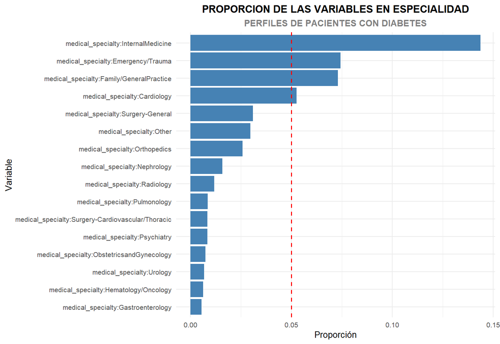

```r
T_Prop_Especialidad %>%
  ggplot(aes(x = reorder(Variable, Proporcion), y = Proporcion)) +
  geom_bar(stat = "identity", fill = "steelblue") +
  geom_hline(yintercept = 0.05, linetype = "dashed", color = "red", size = 0.7) + # Línea horizontal
  coord_flip() +
  ggtitle(label = "PROPORCION DE LAS VARIABLES EN ESPECIALIDAD",
          subtitle = "PERFILES DE PACIENTES CON DIABETES") +
  labs(x = "Variable", y = "Proporción") +
  coord_flip() +
  theme_minimal() +
  theme(plot.title = element_text(size = 12, face = "bold", hjust = 0.5),
        legend.position = "none", text = element_text(size = 10),
        plot.subtitle = element_text(size = 10, face = "bold", hjust = 0.5, color = "grey50"))
```

#### GRF SIN

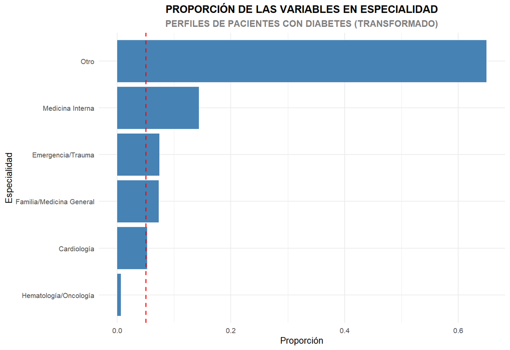

```r
T_Prop_Especialidad_Trans %>%
  ggplot(aes(x = reorder(Especialidad, Proporcion), y = Proporcion)) +
  geom_bar(stat = "identity", fill = "steelblue") +
  geom_hline(yintercept = 0.05, linetype = "dashed", color = "red", size = 0.7) + # Línea horizontal
  coord_flip() +
  ggtitle(label = "PROPORCIÓN DE LAS VARIABLES EN ESPECIALIDAD",
          subtitle = "PERFILES DE PACIENTES CON DIABETES (TRANSFORMADO)") +
  labs(x = "Especialidad", y = "Proporción") +
  theme_minimal() +
  theme(plot.title = element_text(size = 12, face = "bold", hjust = 0.5),
        legend.position = "none", text = element_text(size = 10),
        plot.subtitle = element_text(size = 10, face = "bold", hjust = 0.5, color = "grey50"))
```

### DIAGNOSTICO 1

La variable “diag_1” representa los diagnósticos principales de los pacientes, lo cual es importante para entender la prevalencia de ciertas condiciones en la muestra.

Proporciones de las variables en Diag_1

|  | Variable | Proporción |
| --- | --- | --- |
| 1 | diag_1:Circulatory | 0.2990871 |
| 12 | diag_1:Respiratory | 0.1417313 |
| 3 | diag_1:Digestive | 0.0931085 |
| 2 | diag_1:Diabetes | 0.0860529 |
| 11 | diag_1:Other | 0.0772579 |
| 6 | diag_1:Injury | 0.0685121 |
| 4 | diag_1:Genitourinary | 0.0502835 |
| 8 | diag_1:Musculoskeletal | 0.0487112 |
| 9 | diag_1:Neoplasms | 0.0337352 |
| 5 | diag_1:Infectious | 0.0272005 |
| 10 | diag_1:Non-diabetes endocrine/metabolic | 0.0264045 |
| 13 | diag_1:Skin | 0.0256871 |
| 7 | diag_1:Mental | 0.0222281 |

La mayoría de los casos están relacionados con trastornos circulatorios (29.91%), seguidos de enfermedades respiratorias (14.17%) y digestivas (9.31%). Otras condiciones como diabetes (8.61%), lesiones (6.85%) y trastornos genitourinarios (5.03%) también tienen una representación significativa. Las condiciones más raras incluyen trastornos musculoesqueléticos, neoplasias, infecciones, y trastornos metabólicos, con proporciones menores, lo que sugiere una mayor prevalencia de enfermedades crónicas y comunes en la población.

#### GRF CON

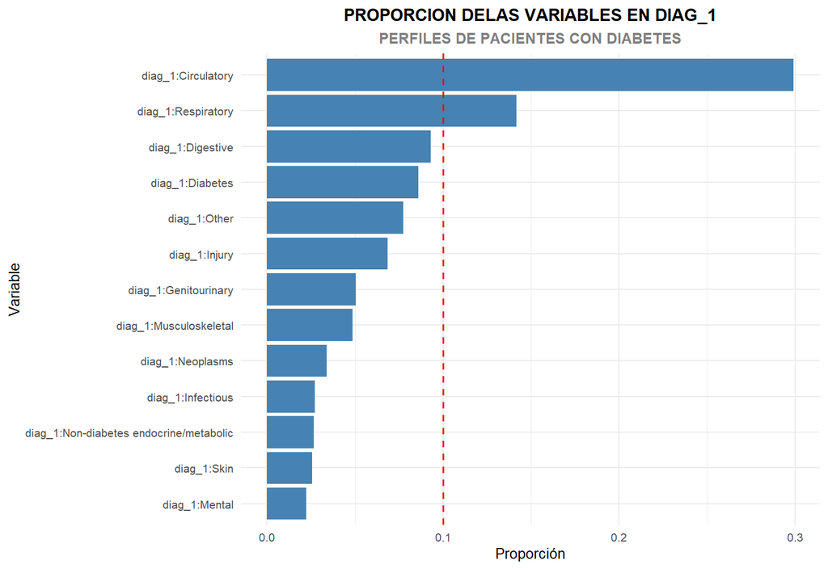

```r
T_Prop_diag1 %>%
  ggplot(aes(x = reorder(Variable, Proporcion), y = Proporcion)) +
  geom_bar(stat = "identity", fill = "steelblue") +
  geom_hline(yintercept = 0.1, linetype = "dashed", color = "red", size = 0.7) + # Línea horizontal
  coord_flip() +
  ggtitle(label = "PROPORCION DELAS VARIABLES EN DIAG_1",
          subtitle = "PERFILES DE PACIENTES CON DIABETES") +
  labs(x = "Variable", y = "Proporción") +
  coord_flip() +
  theme_minimal() +
  theme(plot.title = element_text(size = 12, face = "bold", hjust = 0.5),
        legend.position = "none", text = element_text(size = 10),
        plot.subtitle = element_text(size = 10, face = "bold", hjust = 0.5, color = "grey50"))
```

#### GRF SIN

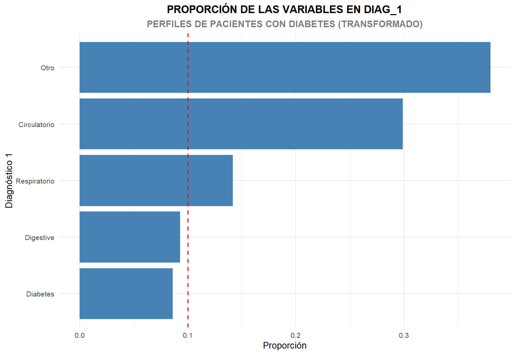

```r
T_Prop_diag %>%
  ggplot(aes(x = reorder(Diagnostico1, Proporcion), y = Proporcion)) +
  geom_bar(stat = "identity", fill = "steelblue") +
  geom_hline(yintercept = 0.1, linetype = "dashed", color = "red", size = 0.7) + # Línea horizontal
  coord_flip() +
  ggtitle(label = "PROPORCIÓN DE LAS VARIABLES EN DIAG_1",
          subtitle = "PERFILES DE PACIENTES CON DIABETES (TRANSFORMADO)") +
  labs(x = "Diagnóstico 1", y = "Proporción") +
  theme_minimal() +
  theme(plot.title = element_text(size = 12, face = "bold", hjust = 0.5),
        legend.position = "none", text = element_text(size = 10),
        plot.subtitle = element_text(size = 10, face = "bold", hjust = 0.5, color = "grey50"))
```

### DIAGNOSTICO 2

La variable “diag_2” refleja el segundo diagnóstico más común entre los pacientes, lo cual proporciona una visión adicional sobre las comorbilidades.

Proporciones de las variables en Diag_2

|  | Variable | Proporción |
| --- | --- | --- |
| 1 | diag_2:Circulatory | 0.3132769 |
| 2 | diag_2:Diabetes | 0.1257235 |
| 12 | diag_2:Respiratory | 0.1070625 |
| 11 | diag_2:Other | 0.1025913 |
| 4 | diag_2:Genitourinary | 0.0823089 |
| 10 | diag_2:Non-diabetes endocrine/metabolic | 0.0807071 |
| 3 | diag_2:Digestive | 0.0409776 |
| 13 | diag_2:Skin | 0.0360642 |
| 7 | diag_2:Mental | 0.0261097 |
| 9 | diag_2:Neoplasms | 0.0250287 |
| 6 | diag_2:Injury | 0.0238397 |
| 5 | diag_2:Infectious | 0.0189755 |
| 8 | diag_2:Musculoskeletal | 0.0173344 |

Al igual que en “diag_1”, los trastornos circulatorios son predominantes (31.33%), seguidos por diabetes (12.57%) y problemas respiratorios (10.71%). Otras condiciones, como enfermedades genitourinarias (8.23%), endocrinas/metabólicas no relacionadas con la diabetes (8.07%), y trastornos digestivos (4.10%), también tienen representaciones importantes. Las condiciones como enfermedades de la piel, trastornos mentales y lesiones son menos comunes, pero siguen siendo relevantes dentro de la población estudiada.

#### GRF CON

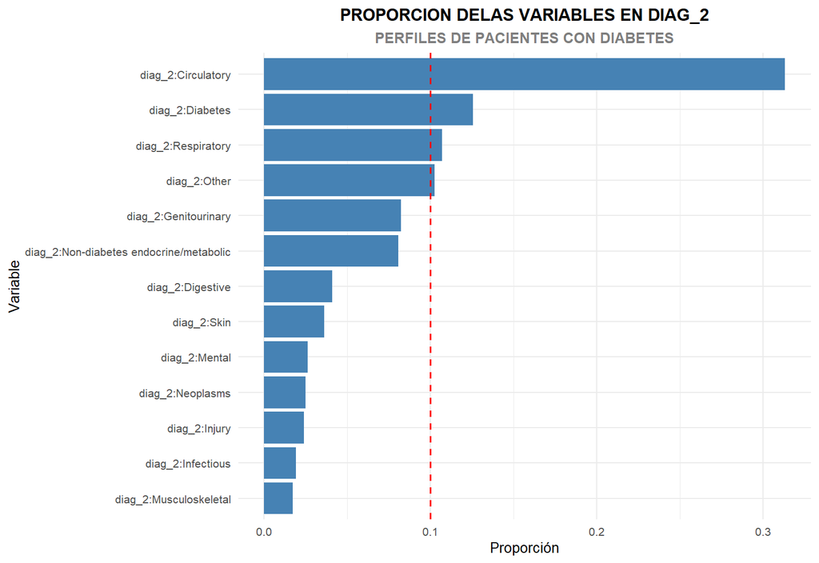

```r
T_Prop_diag2 %>%
  ggplot(aes(x = reorder(Variable, Proporcion), y = Proporcion)) +
  geom_bar(stat = "identity", fill = "steelblue") +
  geom_hline(yintercept = 0.1, linetype = "dashed", color = "red", size = 0.7) + # Línea horizontal
  coord_flip() +
  ggtitle(label = "PROPORCION DELAS VARIABLES EN DIAG_2",
          subtitle = "PERFILES DE PACIENTES CON DIABETES") +
  labs(x = "Variable", y = "Proporción") +
  coord_flip() +
  theme_minimal() +
  theme(plot.title = element_text(size = 12, face = "bold", hjust = 0.5),
        legend.position = "none", text = element_text(size = 10),
        plot.subtitle = element_text(size = 10, face = "bold", hjust = 0.5, color = "grey50"))
```

#### GRF SIN

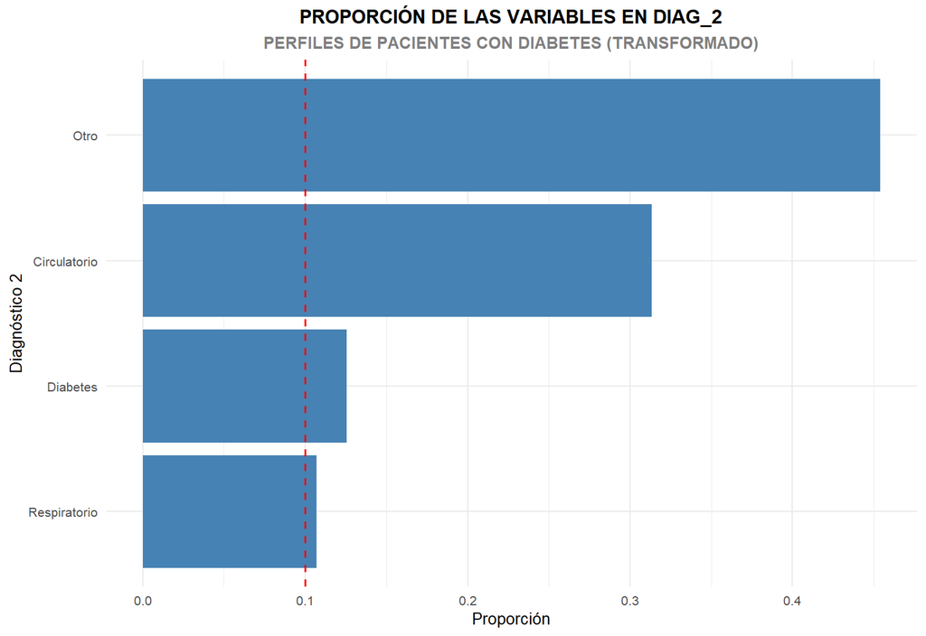

```r
T_Prop_diag %>%
  ggplot(aes(x = reorder(Diagnostico2, Proporcion), y = Proporcion)) +
  geom_bar(stat = "identity", fill = "steelblue") +
  geom_hline(yintercept = 0.1, linetype = "dashed", color = "red", size = 0.7) + # Línea horizontal
  coord_flip() +
  ggtitle(label = "PROPORCIÓN DE LAS VARIABLES EN DIAG_2",
          subtitle = "PERFILES DE PACIENTES CON DIABETES (TRANSFORMADO)") +
  labs(x = "Diagnóstico 2", y = "Proporción") +
  theme_minimal() +
  theme(plot.title = element_text(size = 12, face = "bold", hjust = 0.5),
        legend.position = "none", text = element_text(size = 10),
        plot.subtitle = element_text(size = 10, face = "bold", hjust = 0.5, color = "grey50"))
```

### DIAGNOSTICO 3

La variable “diag_3” representa el tercer diagnóstico más frecuente en los pacientes, brindando más contexto sobre las comorbilidades.

Proporciones de las variables en Diag_3

|  | Variable | Proporción |
| --- | --- | --- |
| 1 | diag_3:Circulatory | 0.2977998 |
| 2 | diag_3:Diabetes | 0.1685976 |
| 11 | diag_3:Other | 0.1362873 |
| 10 | diag_3:Non-diabetes endocrine/metabolic | 0.0898558 |
| 12 | diag_3:Respiratory | 0.0723053 |
| 4 | diag_3:Genitourinary | 0.0656427 |
| 3 | diag_3:Digestive | 0.0386191 |
| 7 | diag_3:Mental | 0.0308167 |
| 13 | diag_3:Skin | 0.0256183 |
| 6 | diag_3:Injury | 0.0191130 |
| 8 | diag_3:Musculoskeletal | 0.0188182 |
| 5 | diag_3:Infectious | 0.0182876 |
| 9 | diag_3:Neoplasms | 0.0182385 |

Al igual que en los diagnósticos anteriores, los trastornos circulatorios son predominantes (29.78%), seguidos por diabetes (16.86%) y diagnósticos “otros” (13.63%). Condiciones como enfermedades endocrinas/metabólicas no relacionadas con la diabetes (8.99%) y respiratorias (7.23%) también son comunes. Otros diagnósticos incluyen problemas genitourinarios (6.56%), digestivos (3.86%), y mentales (3.08%), mientras que trastornos como enfermedades de la piel, lesiones y neoplasias tienen una menor representación.

#### GRF CON

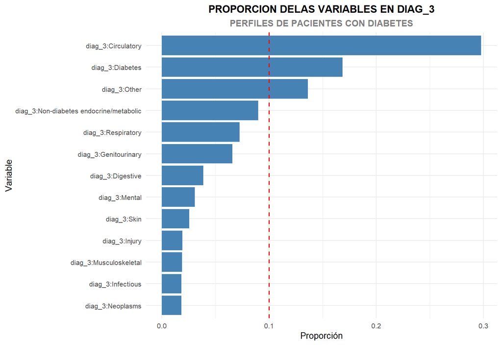

```r
T_Prop_diag3 %>%
  ggplot(aes(x = reorder(Variable, Proporcion), y = Proporcion)) +
  geom_bar(stat = "identity", fill = "steelblue") +
  geom_hline(yintercept = 0.1, linetype = "dashed", color = "red", size = 0.7) + # Línea horizontal
  coord_flip() +
  ggtitle(label = "PROPORCION DELAS VARIABLES EN DIAG_3",
          subtitle = "PERFILES DE PACIENTES CON DIABETES") +
  labs(x = "Variable", y = "Proporción") +
  coord_flip() +
  theme_minimal() +
  theme(plot.title = element_text(size = 12, face = "bold", hjust = 0.5),
        legend.position = "none", text = element_text(size = 10),
        plot.subtitle = element_text(size = 10, face = "bold", hjust = 0.5, color = "grey50"))
```

#### GRF SIN

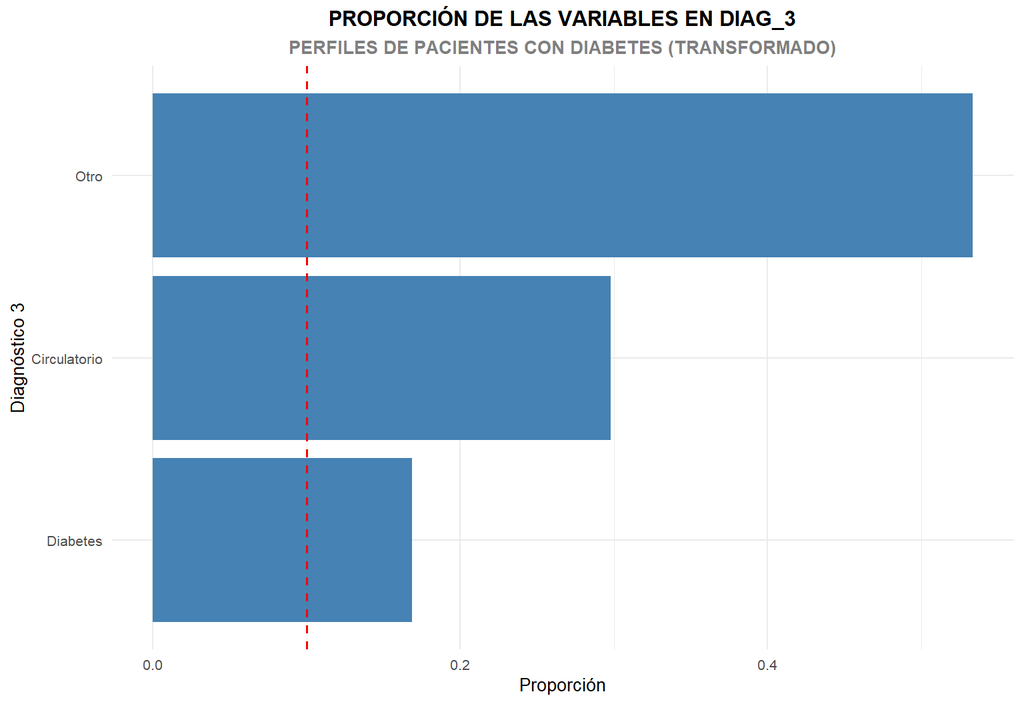

```r
T_Prop_diag %>%
  ggplot(aes(x = reorder(Diagnostico3, Proporcion), y = Proporcion)) +
  geom_bar(stat = "identity", fill = "steelblue") +
  geom_hline(yintercept = 0.1, linetype = "dashed", color = "red", size = 0.7) + # Línea horizontal
  coord_flip() +
  ggtitle(label = "PROPORCIÓN DE LAS VARIABLES EN DIAG_3",
          subtitle = "PERFILES DE PACIENTES CON DIABETES (TRANSFORMADO)") +
  labs(x = "Diagnóstico 3", y = "Proporción") +
  theme_minimal() +
  theme(plot.title = element_text(size = 12, face = "bold", hjust = 0.5),
        legend.position = "none", text = element_text(size = 10),
        plot.subtitle = element_text(size = 10, face = "bold", hjust = 0.5, color = "grey50"))
```

### MEDICAMENTOS

La variable “metformin” indica el cambio en el tratamiento con metformina, un medicamento comúnmente usado para la diabetes.

Proporciones de las variables en Metformin

|  | Variable | Proporción |
| --- | --- | --- |
| 2 | metformin:No | 0.8035927 |
| 3 | metformin:Steady | 0.1802718 |
| 4 | metformin:Up | 0.0104851 |
| 1 | metformin:Down | 0.0056504 |

La mayoría de los pacientes no reciben metformina (80.36%), mientras que una proporción considerable tiene un tratamiento constante con metformina (18.03%). Solo un pequeño porcentaje de los pacientes están en un régimen de aumento (1.05%) o disminución (0.57%) de la dosis de metformina, lo que sugiere que la mayoría de los casos son controlados con una dosis estable o no requieren este tratamiento.

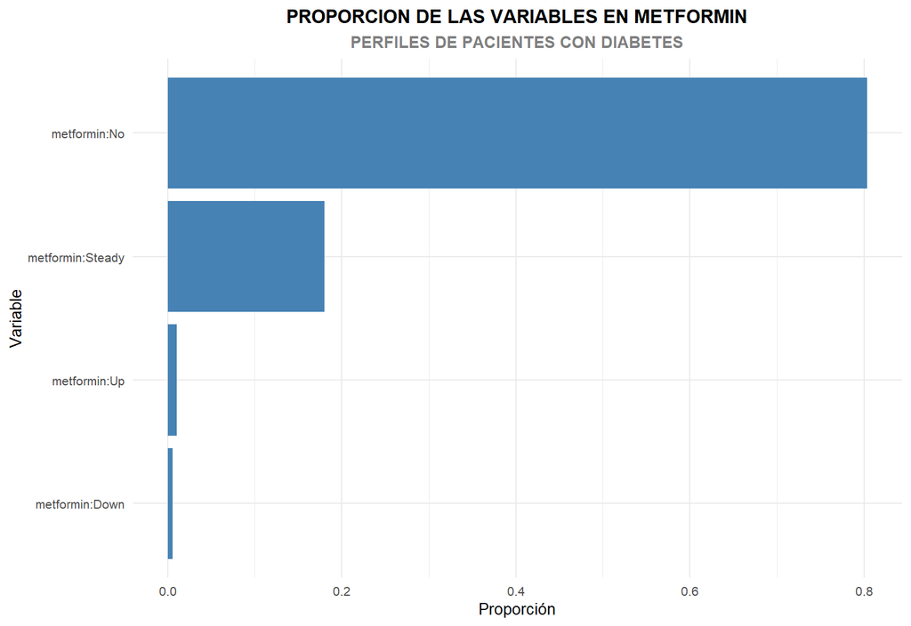

```r
T_Prop_metmorfin %>%
  ggplot(aes(x = reorder(Variable, Proporcion), y = Proporcion)) +
  geom_bar(stat = "identity", fill = "steelblue") +
  coord_flip() +
  ggtitle(label = "PROPORCION DE LAS VARIABLES EN METFORMIN",
          subtitle = "PERFILES DE PACIENTES CON DIABETES") +
  labs(x = "Variable", y = "Proporción") +
  coord_flip() +
  theme_minimal() +
  theme(plot.title = element_text(size = 12, face = "bold", hjust = 0.5),
        legend.position = "none", text = element_text(size = 10),
        plot.subtitle = element_text(size = 10, face = "bold", hjust = 0.5, color = "grey50"))
```

### REPAGLINIDE

La variable “repaglinide” indica el ajuste en el tratamiento con repaglinida, un medicamento utilizado para controlar la diabetes.

Proporciones de las variables en Repaglinide

|  | Variable | Proporción |
| --- | --- | --- |
| 2 | repaglinide:No | 0.9848766 |
| 3 | repaglinide:Steady | 0.0136002 |
| 4 | repaglinide:Up | 0.0010809 |
| 1 | repaglinide:Down | 0.0004422 |

La gran mayoría de los pacientes no reciben repaglinida (98.49%), mientras que una pequeña proporción mantiene una dosis estable (1.36%). Los ajustes en el tratamiento, como el aumento (0.11%) o la disminución (0.04%) de la dosis, son mínimos, lo que sugiere que repaglinida es utilizado de manera muy limitada en la muestra, con la mayoría de los pacientes sin necesidad de este medicamento.

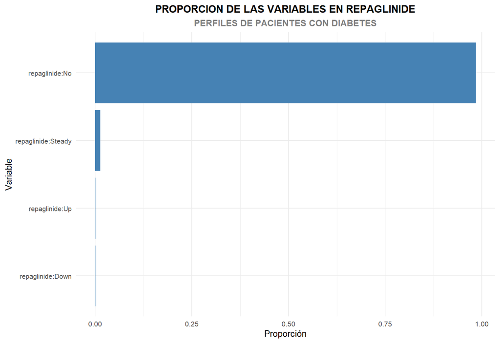

```r
T_Prop_repaglinide %>%
  ggplot(aes(x = reorder(Variable, Proporcion), y = Proporcion)) +
  geom_bar(stat = "identity", fill = "steelblue") +
  coord_flip() +
  ggtitle(label = "PROPORCION DE LAS VARIABLES EN REPAGLINIDE",
          subtitle= "PERFILES DE PACIENTES CON DIABETES") +
  labs(x = "Variable", y = "Proporción") +
  coord_flip() +
  theme_minimal() +
  theme(plot.title = element_text(size = 12, face = "bold", hjust = 0.5),
        legend.position = "none", text = element_text(size = 10),
        plot.subtitle = element_text(size = 10, face = "bold", hjust = 0.5, color = "grey50"))
```

### NATEGLINIDE

La variable “nateglinide” refleja el uso y ajuste en el tratamiento con nateglinida, otro medicamento utilizado para la diabetes.

Proporciones de las variables en Nateglinide

|  | Variable | Proporción |
| --- | --- | --- |
| 2 | nateglinide:No | 0.9930918 |
| 3 | nateglinide:Steady | 0.0065643 |
| 4 | nateglinide:Up | 0.0002358 |
| 1 | nateglinide:Down | 0.0001081 |

La gran mayoría de los pacientes no reciben nateglinida (99.31%), con una pequeña proporción manteniendo una dosis estable (0.66%). Los ajustes en la dosis, como el aumento (0.02%) o la disminución (0.01%), son mínimos, lo que indica que este medicamento tiene una utilización muy baja en la muestra, con la mayoría de los pacientes sin necesidad de tratamiento con nateglinida.

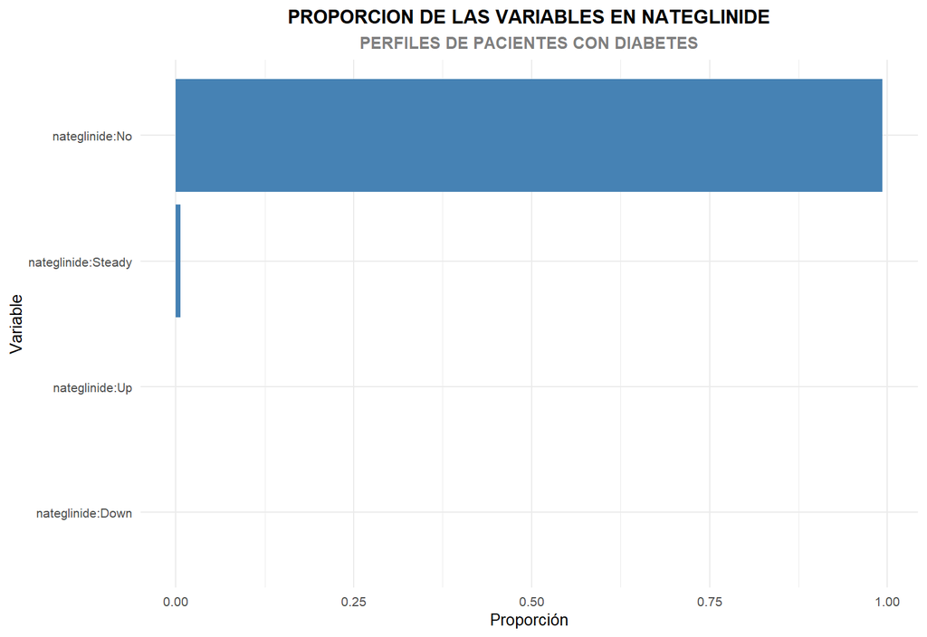

```r
T_Prop_nateglinide %>%
  ggplot(aes(x = reorder(Variable, Proporcion), y = Proporcion)) +
  geom_bar(stat = "identity", fill = "steelblue") +
  coord_flip() +
  ggtitle(label = "PROPORCION DE LAS VARIABLES EN NATEGLINIDE",
          subtitle = "PERFILES DE PACIENTES CON DIABETES") +
  labs(x = "Variable", y = "Proporción") +
  coord_flip() +
  theme_minimal() +
  theme(plot.title = element_text(size = 12, face = "bold", hjust = 0.5),
        legend.position = "none", text = element_text(size = 10),
        plot.subtitle = element_text(size = 10, face = "bold", hjust = 0.5, color = "grey50"))
```

### CLORPROPAMIDA

La variable “chlorpropamide” muestra el uso y ajuste en el tratamiento con clorpropamida, un medicamento para la diabetes.

Proporciones de las variables en Chlorpropamide

|  | Variable | Proporción |
| --- | --- | --- |
| 2 | chlorpropamide:No | 0.9991549 |
| 3 | chlorpropamide:Steady | 0.0007763 |
| 4 | chlorpropamide:Up | 0.0000590 |
| 1 | chlorpropamide:Down | 0.0000098 |

La mayoría de los pacientes no reciben clorpropamida (99.92%), mientras que una pequeña fracción mantiene una dosis estable (0.08%). Los ajustes en la dosis, como el aumento (0.01%) o la disminución (menos del 0.01%), son prácticamente inexistentes, lo que indica que este medicamento es utilizado en una proporción extremadamente baja dentro de la muestra, con la mayoría de los pacientes no requiriendo tratamiento con clorpropamida.

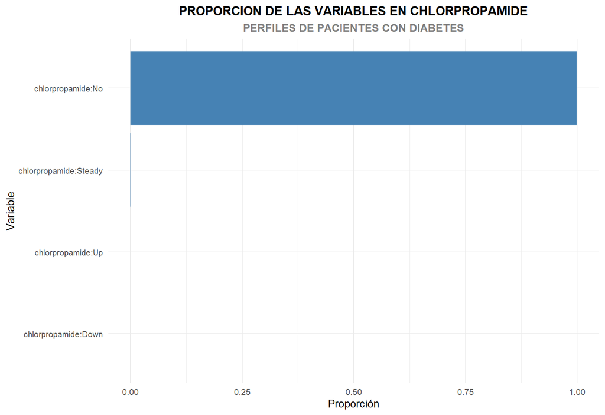

```r
T_Prop_chlorpropamide %>%
  ggplot(aes(x = reorder(Variable, Proporcion), y = Proporcion)) +
  geom_bar(stat = "identity", fill = "steelblue") +
  coord_flip() +
  ggtitle(label = "PROPORCION DE LAS VARIABLES EN CHLORPROPAMIDE",
          subtitle = "PERFILES DE PACIENTES CON DIABETES") +
  labs(x = "Variable", y = "Proporción") +
  coord_flip() +
  theme_minimal() +
  theme(plot.title = element_text(size = 12, face = "bold", hjust = 0.5),
        legend.position = "none", text = element_text(size = 10),
        plot.subtitle = element_text(size = 10, face = "bold", hjust = 0.5, color = "grey50"))
```

|  | Variable | Proporción |
| --- | --- | --- |
| 2 | glipizide:No | 0.8753476 |
| 3 | glipizide:Steady | 0.1115828 |
| 4 | glipizide:Up | 0.0075666 |
| 1 | glipizide:Down | 0.0055030 |

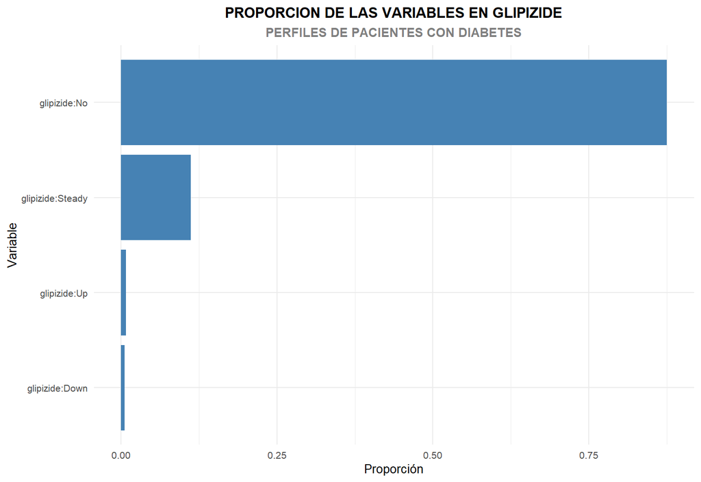

```r
T_Prop_glipizide %>%
  ggplot(aes(x = reorder(Variable, Proporcion), y = Proporcion)) +
  geom_bar(stat = "identity", fill = "steelblue") +
  coord_flip() +
  ggtitle(label = "PROPORCION DE LAS VARIABLES EN GLIPIZIDE",
          subtitle = "PERFILES DE PACIENTES CON DIABETES") +
  labs(x = "Variable", y = "Proporción") +
  coord_flip() +
  theme_minimal() +
  theme(plot.title = element_text(size = 12, face = "bold", hjust = 0.5),
        legend.position = "none", text = element_text(size = 10),
        plot.subtitle = element_text(size = 10, face = "bold", hjust = 0.5, color = "grey50"))
```

### GLYBURIDE

La variable “glyburide” indica el uso y ajuste en el tratamiento con gliburida, un medicamento utilizado para la diabetes.

|  | Variable | Proporción |
| --- | --- | --- |
| 2 | glyburide:No | 0.8953451 |
| 3 | glyburide:Steady | 0.0911333 |
| 4 | glyburide:Up | 0.0079793 |
| 1 | glyburide:Down | 0.0055423 |

La mayoría de los pacientes no reciben glyburide (89.53%), mientras que una proporción menor mantiene una dosis constante (9.11%). Los ajustes en la dosis, como el aumento (0.80%) o la disminución (0.55%), son mínimos, lo que sugiere que la mayoría de los pacientes no requieren este medicamento o lo mantienen a una dosis estable.

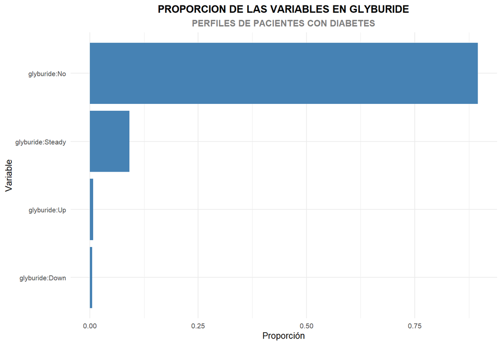

```r
T_Prop_glyburide %>%
  ggplot(aes(x = reorder(Variable, Proporcion), y = Proporcion)) +
  geom_bar(stat = "identity", fill = "steelblue") +
  coord_flip() +
  ggtitle(label = "PROPORCION DE LAS VARIABLES EN GLYBURIDE",
          subtitle = "PERFILES DE PACIENTES CON DIABETES") +
  labs(x = "Variable", y = "Proporción") +
  coord_flip() +
  theme_minimal() +
  theme(plot.title = element_text(size = 12, face = "bold", hjust = 0.5),
        legend.position = "none", text = element_text(size = 10),
        plot.subtitle = element_text(size = 10, face = "bold", hjust = 0.5, color = "grey50"))
```

### GLIMEPRIDE

La variable “glimepiride” refleja el uso y ajuste en el tratamiento con glimepirida, un medicamento para la diabetes.

Proporciones de las variables en Glimepiride

|  | Variable | Proporción |
| --- | --- | --- |
| 2 | glimepiride:No | 0.9489893 |
| 3 | glimepiride:Steady | 0.0458909 |
| 4 | glimepiride:Up | 0.0032133 |
| 1 | glimepiride:Down | 0.0019064 |

La gran mayoría de los pacientes no reciben glimepirida (94.90%), mientras que una pequeña proporción mantiene una dosis estable (4.59%). Los ajustes en la dosis, como el aumento (0.32%) o la disminución (0.19%), son mínimos, lo que sugiere que este medicamento se utiliza en una proporción reducida de pacientes y, en su mayoría, con una dosis constante.

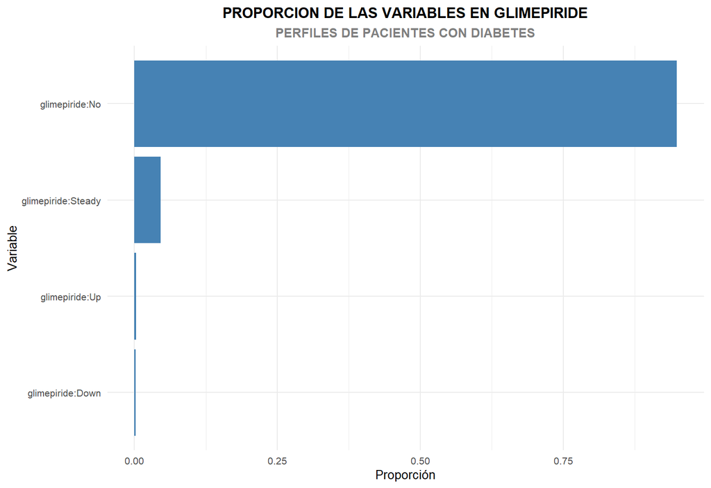

```r
T_Prop_glimepiride %>%
  ggplot(aes(x = reorder(Variable, Proporcion), y = Proporcion)) +
  geom_bar(stat = "identity", fill = "steelblue") +
  coord_flip() +
  ggtitle(label = "PROPORCION DE LAS VARIABLES EN GLIMEPIRIDE",
          subtitle = "PERFILES DE PACIENTES CON DIABETES") +
  labs(x = "Variable", y = "Proporción") +
  coord_flip() +
  theme_minimal() +
  theme(plot.title = element_text(size = 12, face = "bold", hjust = 0.5),
        legend.position = "none", text = element_text(size = 10),
        plot.subtitle = element_text(size = 10, face = "bold", hjust = 0.5, color = "grey50"))
```

### PIOGLITAZONE

La variable “pioglitazone” muestra el uso y ajuste en el tratamiento con pioglitazona, un medicamento utilizado para la diabetes.

Proporciones de las variables en Pioglitazone

|  | Variable | Proporción |
| --- | --- | --- |
| 2 | pioglitazone:No | 0.9279994 |
| 3 | pioglitazone:Steady | 0.0685416 |
| 4 | pioglitazone:Up | 0.0022995 |
| 1 | pioglitazone:Down | 0.0011596 |

La mayoría de los pacientes no reciben pioglitazona (92.80%), mientras que una pequeña proporción mantiene una dosis constante (6.85%). Los ajustes en la dosis, como el aumento (0.23%) o la disminución (0.12%), son mínimos, lo que indica que este medicamento es utilizado por una minoría de pacientes y principalmente a dosis estables.

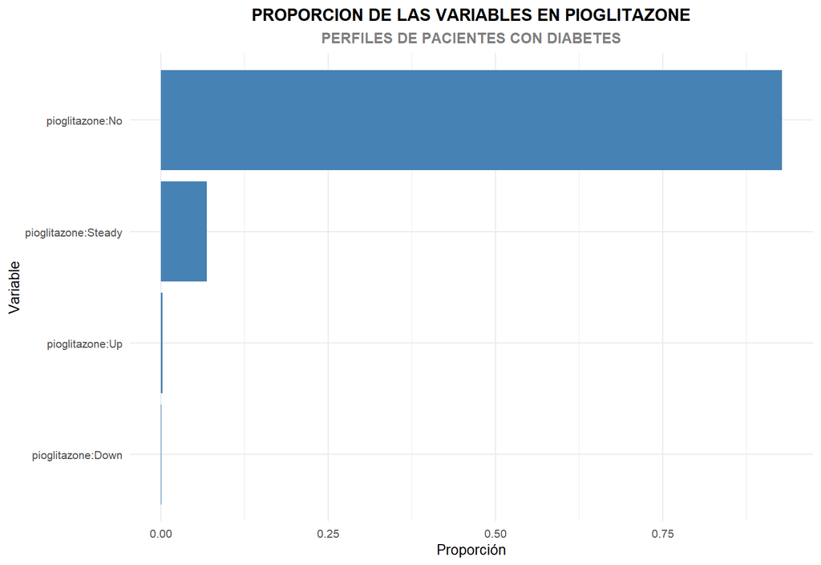

```r
T_Prop_pioglitazone %>%
  ggplot(aes(x = reorder(Variable, Proporcion), y = Proporcion)) +
  geom_bar(stat = "identity", fill = "steelblue") +
  coord_flip() +
  ggtitle(label = "PROPORCION DE LAS VARIABLES EN PIOGLITAZONE",
          subtitle = "PERFILES DE PACIENTES CON DIABETES") +
  labs(x = "Variable", y = "Proporción") +
  coord_flip() +
  theme_minimal() +
  theme(plot.title = element_text(size = 12, face = "bold", hjust = 0.5),
        legend.position = "none", text = element_text(size = 10),
        plot.subtitle = element_text(size = 10, face = "bold", hjust = 0.5, color = "grey50"))
```

### ROSIGLITAZONE

La variable “rosiglitazone” refleja el uso y ajuste en el tratamiento con rosiglitazona, un medicamento utilizado para tratar la diabetes.

Proporciones de las variables en Rosiglitazone

|  | Variable | Proporción |
| --- | --- | --- |
| 2 | rosiglitazone:No | 0.9374625 |
| 3 | rosiglitazone:Steady | 0.0599334 |
| 4 | rosiglitazone:Up | 0.0017492 |
| 1 | rosiglitazone:Down | 0.0008549 |

La mayoría de los pacientes no reciben rosiglitazona (93.75%), mientras que una pequeña fracción mantiene una dosis constante (5.99%). Los ajustes en la dosis, como el aumento (0.17%) o la disminución (0.09%), son mínimos, lo que sugiere que rosiglitazona es utilizado en una pequeña proporción de pacientes, y en su mayoría, el tratamiento se mantiene estable.

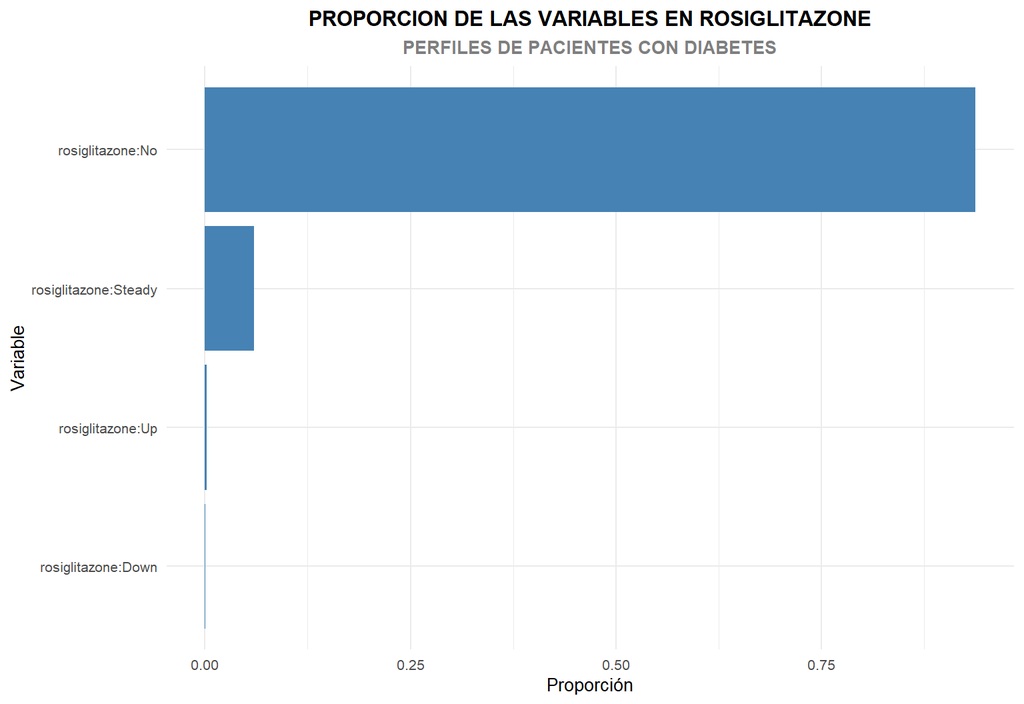

```r
T_Prop_rosiglitazone %>%
  ggplot(aes(x = reorder(Variable, Proporcion), y = Proporcion)) +
  geom_bar(stat = "identity", fill = "steelblue") +
  coord_flip() +
  ggtitle(label = "PROPORCION DE LAS VARIABLES EN ROSIGLITAZONE",
          subtitle = "PERFILES DE PACIENTES CON DIABETES") +
  labs(x = "Variable", y = "Proporción") +
  coord_flip() +
  theme_minimal() +
  theme(plot.title = element_text(size = 12, face = "bold", hjust = 0.5),
        legend.position = "none", text = element_text(size = 10),
        plot.subtitle = element_text(size = 10, face = "bold", hjust = 0.5, color = "grey50"))
```

### ACARBOSE

La variable “acarbose” refleja el uso y ajuste en el tratamiento con acarbosa, un medicamento utilizado para controlar la diabetes.

Proporciones de las variables en Acarbose

|  | Variable | Proporción |
| --- | --- | --- |
| 2 | acarbose:No | 0.9969734 |
| 3 | acarbose:Steady | 0.0028989 |
| 4 | acarbose:Up | 0.0000983 |
| 1 | acarbose:Down | 0.0000295 |

La gran mayoría de los pacientes no reciben acarbosa (99.70%), mientras que una pequeña fracción mantiene una dosis constante (0.29%). Los ajustes en la dosis, como el aumento (0.01%) o la disminución (menos del 0.01%), son prácticamente inexistentes, lo que indica que acarbosa es utilizado en una proporción extremadamente baja de pacientes y, cuando se usa, generalmente a dosis estables.

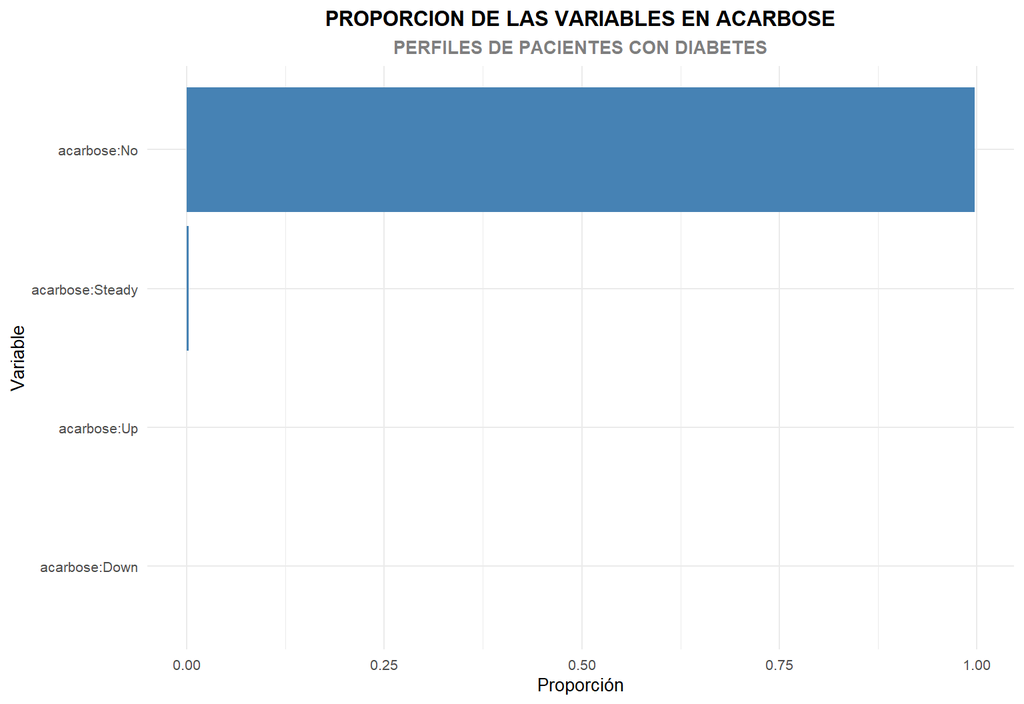

```r
T_Prop_acarbose %>%
  ggplot(aes(x = reorder(Variable, Proporcion), y = Proporcion)) +
  geom_bar(stat = "identity", fill = "steelblue") +
  coord_flip() +
  ggtitle(label = "PROPORCION DE LAS VARIABLES EN ACARBOSE",
          subtitle = "PERFILES DE PACIENTES CON DIABETES") +
  labs(x = "Variable", y = "Proporción") +
  coord_flip() +
  theme_minimal() +
  theme(plot.title = element_text(size = 12, face = "bold", hjust = 0.5),
        legend.position = "none", text = element_text(size = 10),
        plot.subtitle = element_text(size = 10, face = "bold", hjust = 0.5, color = "grey50"))
```

### MIGLITOL

La variable “miglitol” refleja el uso y ajuste en el tratamiento con miglitol, un medicamento utilizado para controlar la diabetes.

Proporciones de las variables en Miglitol

|  | Variable | Proporción |
| --- | --- | --- |
| 2 | miglitol:No | 0.9996266 |
| 3 | miglitol:Steady | 0.0003046 |
| 1 | miglitol:Down | 0.0000491 |
| 4 | miglitol:Up | 0.0000197 |

La gran mayoría de los pacientes no reciben miglitol (99.96%), con una pequeña proporción manteniendo una dosis constante (0.03%). Los ajustes en la dosis, como el aumento (0.002%) o la disminución (menos del 0.01%), son prácticamente inexistentes, lo que indica que miglitol es utilizado en una proporción extremadamente baja de pacientes y, cuando se utiliza, generalmente a dosis estables.

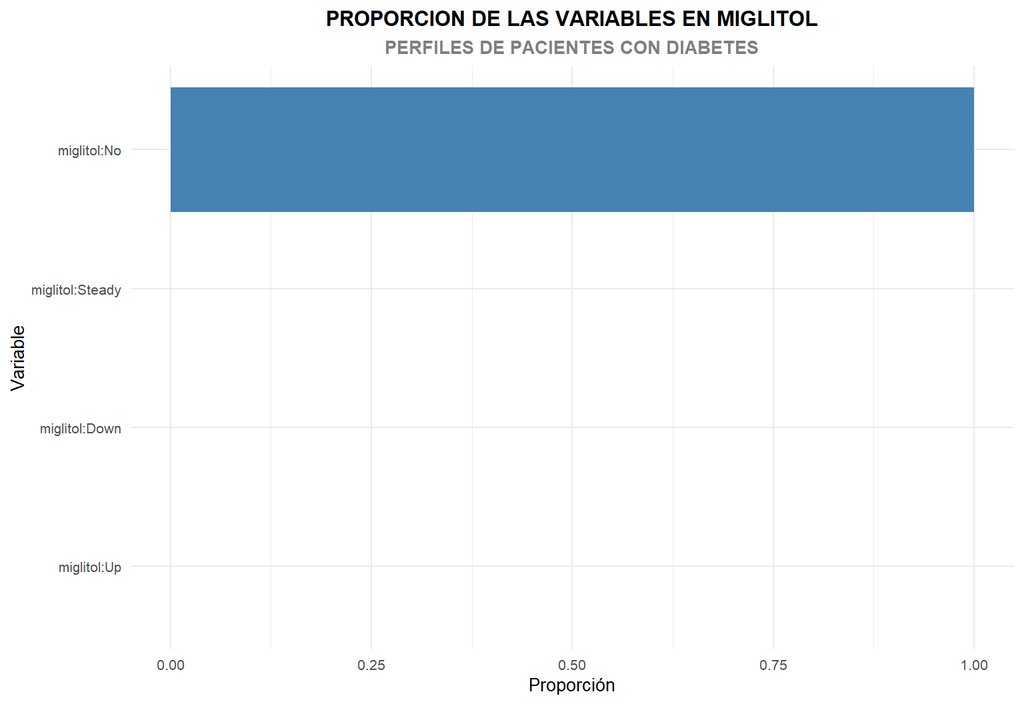

```r
T_Prop_miglitol %>%
  ggplot(aes(x = reorder(Variable, Proporcion), y = Proporcion)) +
  geom_bar(stat = "identity", fill = "steelblue") +
  coord_flip() +
  ggtitle(label = "PROPORCION DE LAS VARIABLES EN MIGLITOL",
          subtitle = "PERFILES DE PACIENTES CON DIABETES") +
  labs(x = "Variable", y = "Proporción") +
  coord_flip() +
  theme_minimal() +
  theme(plot.title = element_text(size = 12, face = "bold", hjust = 0.5),
        legend.position = "none", text = element_text(size = 10),
        plot.subtitle = element_text(size = 10, face = "bold", hjust = 0.5, color = "grey50"))
```

```r
data <- data %>%
  mutate(Miglitol = case_when(
    `miglitol:Down` == 1 ~ "Disminuido",
    `miglitol:No` == 1 ~ "No",
    `miglitol:Steady` == 1 ~ "Estable",
    `miglitol:Up` == 1 ~ "Aumentado",
    TRUE ~ "Desconocido"
  ))

data <- data %>%
  select(-`miglitol:Down`, -`miglitol:No`, -`miglitol:Steady`, -`miglitol:Up`)
```

### TOLAZAMIDA

La variable “tolazamide” muestra el uso y ajuste en el tratamiento con tolazamida, un medicamento utilizado para tratar la diabetes.

Proporciones de las variables en Tolazamide

| Variable | Proporción |
| --- | --- |
| tolazamide:No | 0.9996168 |
| tolazamide:Steady | 0.0003734 |
| tolazamide:Up | 0.0000098 |

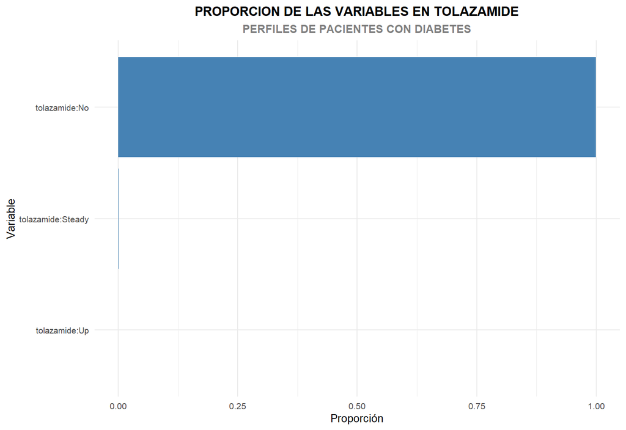

```r
T_Prop_tolazamide %>%
  ggplot(aes(x = reorder(Variable, Proporcion), y = Proporcion)) +
  geom_bar(stat = "identity", fill = "steelblue") +
  coord_flip() +
  ggtitle(label = "PROPORCION DE LAS VARIABLES EN TOLAZAMIDE",
          subtitle = "PERFILES DE PACIENTES CON DIABETES") +
  labs(x = "Variable", y = "Proporción") +
  coord_flip() +
  theme_minimal() +
  theme(plot.title = element_text(size = 12, face = "bold", hjust = 0.5),
        legend.position = "none", text = element_text(size = 10),
        plot.subtitle = element_text(size = 10, face = "bold", hjust = 0.5, color = "grey50"))
```

### INSULINA

La variable “insulin” indica el uso y ajuste en el tratamiento con insulina.

Proporciones de las variables en Insulin

|  | Variable | Proporción |
| --- | --- | --- |
| 2 | insulin:No | 0.4655916 |
| 3 | insulin:Steady | 0.3031455 |
| 1 | insulin:Down | 0.1200633 |
| 4 | insulin:Up | 0.1111996 |

La distribución muestra que una proporción considerable de pacientes no recibe insulina (46.56%), mientras que una parte significativa tiene una dosis estable (30.31%). Además, un 12.01% de los pacientes experimenta una disminución en la dosis, y un 11.12% tiene un aumento en la dosis de insulina. Esto sugiere que, aunque una proporción significativa no utiliza insulina, aquellos que la usan tienen ajustes en sus dosis, lo que refleja variabilidad en el tratamiento.

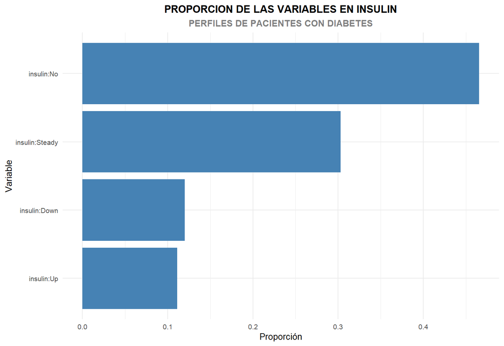

```r
T_Prop_insulin %>%
  ggplot(aes(x = reorder(Variable, Proporcion), y = Proporcion)) +
  geom_bar(stat = "identity", fill = "steelblue") +
  coord_flip() +
  ggtitle(label = "PROPORCION DE LAS VARIABLES EN INSULIN",
          subtitle = "PERFILES DE PACIENTES CON DIABETES") +
  labs(x = "Variable", y = "Proporción") +
  coord_flip() +
  theme_minimal() +
  theme(plot.title = element_text(size = 12, face = "bold", hjust = 0.5),
        legend.position = "none", text = element_text(size = 10),
        plot.subtitle = element_text(size = 10, face = "bold", hjust = 0.5, color = "grey50"))
```

La variable “glyburide-metformin” refleja el uso y ajuste en el tratamiento con una combinación de glyburide y metformina, medicamentos utilizados para controlar la diabetes.

Proporciones de las variables en Glyburide-Metformin

|  | Variable | Proporción |
| --- | --- | --- |
| 2 | glyburide-metformin:No | 0.9930623 |
| 3 | glyburide-metformin:Steady | 0.0068001 |
| 4 | glyburide-metformin:Up | 0.0000786 |
| 1 | glyburide-metformin:Down | 0.0000590 |

La gran mayoría de los pacientes no reciben este tratamiento combinado (99.31%), mientras que una pequeña fracción mantiene una dosis constante (0.68%). Los ajustes en la dosis, como el aumento (0.01%) o la disminución (menos del 0.01%), son prácticamente inexistentes, lo que indica que este tratamiento combinado es utilizado en una proporción mínima de pacientes y generalmente a dosis estables.

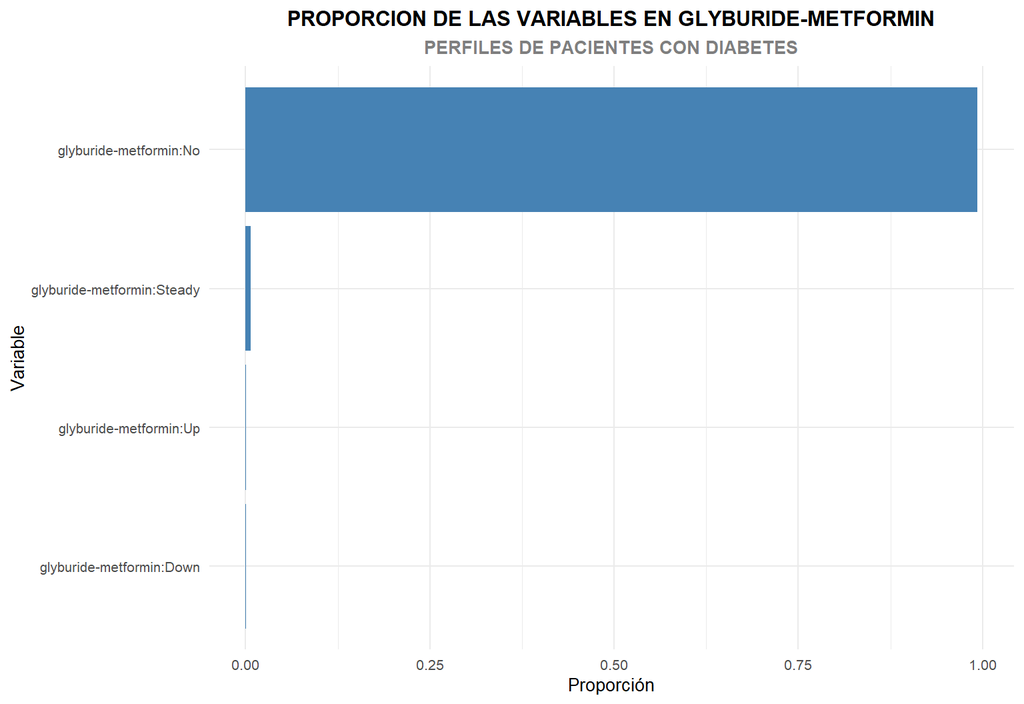

```r
T_Prop_glyburide_metformin %>%
  ggplot(aes(x = reorder(Variable, Proporcion), y = Proporcion)) +
  geom_bar(stat = "identity", fill = "steelblue") +
  coord_flip() +
  ggtitle(label = "PROPORCION DE LAS VARIABLES EN GLYBURIDE-METFORMIN",
          subtitle = "PERFILES DE PACIENTES CON DIABETES") +
  labs(x = "Variable", y = "Proporción") +
  coord_flip() +
  theme_minimal() +
  theme(plot.title = element_text(size = 12, face = "bold", hjust = 0.5),
        legend.position = "none", text = element_text(size = 10),
        plot.subtitle = element_text(size = 10, face = "bold", hjust = 0.5, color = "grey50"))
```

### A1CRESULT

La variable “A1Cresult” refleja los resultados de las pruebas de hemoglobina A1c, que indican el control a largo plazo de la glucosa en sangre en pacientes con diabetes.

Proporciones de las variables en A1Cresult

|  | Variable | Proporción |
| --- | --- | --- |
| 2 | A1Cresult:None | 0.8327683 |
| 4 | A1Cresult:>8 | 0.0807366 |
| 1 | A1Cresult:Norm | 0.0490355 |
| 3 | A1Cresult:>7 | 0.0374596 |

La mayoría de los pacientes no tienen un resultado A1c registrado (83.28%), lo que podría indicar que los datos no fueron obtenidos o no se realizaron pruebas. De los pacientes con resultados, una proporción significativa tiene un A1c mayor a 8 (>8) (8.07%), lo que indica un mal control de la glucosa. Un porcentaje menor muestra un resultado dentro del rango normal (4.90%) o con A1c entre 7 y 8 (>7) (3.75%). Esto sugiere que una proporción significativa de pacientes no tiene resultados de A1c registrados, y aquellos que lo tienen, en su mayoría, presentan un mal control de la glucosa.

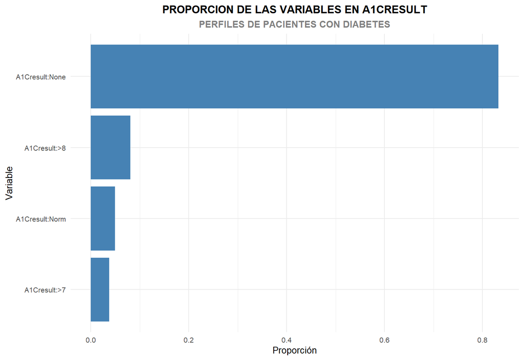

```r
T_Prop_A1Cresult %>%
  ggplot(aes(x = reorder(Variable, Proporcion), y = Proporcion)) +
  geom_bar(stat = "identity", fill = "steelblue") +
  coord_flip() +
  ggtitle(label = "PROPORCION DE LAS VARIABLES EN A1CRESULT",
          subtitle = "PERFILES DE PACIENTES CON DIABETES") +
  labs(x = "Variable", y = "Proporción") +
  coord_flip() +
  theme_minimal() +
  theme(plot.title = element_text(size = 12, face = "bold", hjust = 0.5),
        legend.position = "none", text = element_text(size = 10),
        plot.subtitle = element_text(size = 10, face = "bold", hjust = 0.5, color = "grey50"))
```

### MAX GLU SERUM

La variable “max_glu_serum” refleja los resultados del nivel máximo de glucosa en suero de los pacientes.

Proporciones de las variables en Max Glu Serum

|  | Variable | Proporción |
| --- | --- | --- |
| 2 | max_glu_serum:None | 0.9474662 |
| 1 | max_glu_serum:Norm | 0.0255201 |
| 3 | max_glu_serum:>200 | 0.0145927 |
| 4 | max_glu_serum:>300 | 0.0124210 |

La mayoría de los pacientes no tienen un resultado registrado para este análisis (94.75%), lo que podría indicar que no se realizaron pruebas o no se disponen de los datos. De los pacientes con resultados, una pequeña proporción tiene niveles normales de glucosa en suero (2.55%), mientras que un porcentaje menor presenta niveles superiores a 200 mg/dL (>200) (1.46%) o superiores a 300 mg/dL (>300) (1.24%), lo que sugiere un control insuficiente de la glucosa en sangre en estos casos.

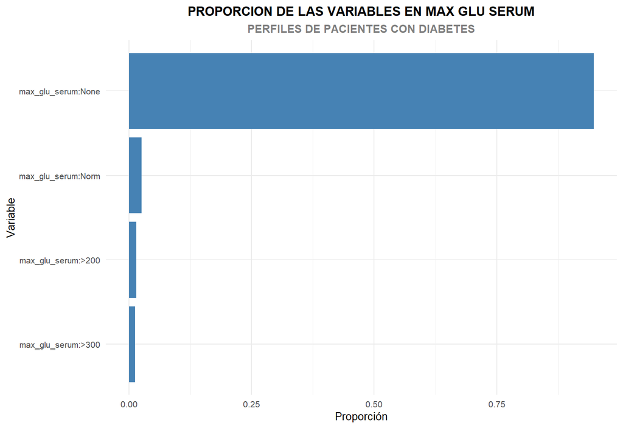

```r
T_Prop_max_glu_serum %>%
  ggplot(aes(x = reorder(Variable, Proporcion), y = Proporcion)) +
  geom_bar(stat = "identity", fill = "steelblue") +
  coord_flip() +
  ggtitle(label = "PROPORCION DE LAS VARIABLES EN MAX GLU SERUM",
          subtitle = "PERFILES DE PACIENTES CON DIABETES") +
  labs(x = "Variable", y = "Proporción") +
  coord_flip() +
  theme_minimal() +
  theme(plot.title = element_text(size = 12, face = "bold", hjust = 0.5),
        legend.position = "none", text = element_text(size = 10),
        plot.subtitle = element_text(size = 10, face = "bold", hjust = 0.5, color = "grey50"))
```